# PSTAT 220A Homework 2

Jaxon Stuhr

2022-10-19

# Question 1

For each of Examples A-J (except C) in the file hw2scan.pdf, state which of the following tests you would apply and (briefly) why: paired t-test, singed rank test, two sample t-test (equal variances or unequal variances), Wilcoxon rank test, other. Conduct appropriate tests.

- Example A: Paired t-test, The dependent variable is interval and the observations are paired (twins)

```
##
##  Paired t-test
##
## data:  honey and no_honey
## t = 4.7254, df = 5, p-value = 0.005218
## alternative hypothesis: true mean difference is not equal to 0
## 95 percent confidence interval:
##   4.028033 13.638633
## sample estimates:
## mean difference
##        8.833333
```

- Example B: Paired t-test: The dependent variable is interval and the observations are paired (two observations for one individual, before and after drug)

```
##
##  Paired t-test
##
## data:  before and after
## t = 2.7885, df = 11, p-value = 0.01763
## alternative hypothesis: true mean difference is not equal to 0
## 95 percent confidence interval:
##   2.423084 20.576916
## sample estimates:
## mean difference
##            11.5
```

- Example D: Wilcoxon rank test: Dependent variable is ordinal and observations are two independent groups

```
##
##  Wilcoxon rank sum test with continuity correction
##
## data:  oxygen_gel and placebo_gel
## W = 801.5, p-value = 8.354e-05
## alternative hypothesis: true location shift is not equal to 0
```

The individuals who took the oxygen gel had significantly higher Oral Hygiene Index, with p << .05

- Example E: Two-Sample t-test, equal variances: The dependent variable is interval and the observations are from independent groups, with visually similar Standard Deviations

```
##
##  Two Sample t-test
##
## data:  pot_chlorate and electrolytic
## t = 0.68915, df = 15, p-value = 0.5013
## alternative hypothesis: true difference in means is not equal to 0
## 95 percent confidence interval:
##  -0.0002110813  0.0004127955
## sample estimates:
## mean of x mean of y
##  1.429183  1.429082
```

There was not significant difference between the samples and we cannot reject the null hypothesis that the true mean is not the true density of oxygen. P-value = .5013.

- Example F: Two-Sample t-test, unequal variances: The dependent variable is interval and the observations are from independent groups, with visually different Standard Deviations

```
##
##  Welch Two Sample t-test
##
## data:  chem_compounds and air
## t = -21.734, df = 7.1476, p-value = 8.594e-08
## alternative hypothesis: true difference in means is not equal to 0
## 95 percent confidence interval:
##  -0.01180801 -0.00949949
## sample estimates:
## mean of x mean of y
##  2.299473  2.310126
```

There was significant difference between the two samples, and we can reject the null that the shared mean is the true density of nitrogen. P-value << .05.

- Example G: Two-Sample t-test, equal variances: The dependent variable is interval and the observations are from independent groups, with similar Standard Deviations

```
##
##  Two Sample t-test
##
## data:  music and no_music
## t = 1.5457, df = 16, p-value = 0.1417
## alternative hypothesis: true difference in means is not equal to 0
## 95 percent confidence interval:
##  -5.175961 33.042627
## sample estimates:
## mean of x mean of y
##  59.22222  45.28889
```

There was not significant difference between the samples (P-value = .1417), and we cannot reject the null that there is no affect of listening to music on productivity.

- Example H: Two-Sample t-test, equal variances: The dependent variable is interval and the observations are from independent groups, with similar Standard Deviations

```
##
##  Two Sample t-test
##
## data:  males and females
## t = -0.023186, df = 13, p-value = 0.9819
## alternative hypothesis: true difference in means is not equal to 0
## 95 percent confidence interval:
##  -125.5648  122.8981
## sample estimates:
## mean of x mean of y
##  138.6667  140.0000
```

There is no significant difference in the number of trials it took male vs female kittens, and we cannot reject the null that they have similar pattern recognition capabilities.

- Example I: Two-Sample t-test, unequal variances: The dependent variable is interval and the observations are from independent groups, with difference Standard Deviations

```
## [1] "p-value =  4.62984568537978e-30"
```

There is significant difference in means and we can reject the null that there is no impact of activity levels on the lifetimes of flies. p-value << .05

- Example J: Two-Sample t-test, unequal variances: The dependent variable is interval and the observations are from independent groups, with difference Standard Deviations

```
## [1] "p-values: 2.46181728966564e-126 7.9603510728832e-28 3.28634024834041e-96"
```

There is significant difference between each sample and the other two, and we can reject the nulls that:

1. There is no impact of Permanent O2 exposure on fly-lifetime relative to a control
2. There is no impact of Temporary O2 exposure on fly-lifetime relative to a control
3. There is equal impact of Permanent and Temporary O2 exposure on fly-lifetime

# Question 2

For Example C in the file hw2scan.pdf, you may apply one of the above simple tests to the combined data across experiments. Is this a reasonable approach for this particular data? Why or why not? Suppose this is not reasonable, can you suggest an alternative approach?

I will apply a Paired t-test as the dependent variable is interval and the observations are paired (pairs of rats from the same litter).

```
##
##  Paired t-test
##
## data:  treatment and control
## t = 5.7695, df = 22, p-value = 8.365e-06
## alternative hypothesis: true mean difference is not equal to 0
## 95 percent confidence interval:
##  23.11535 49.05856
## sample estimates:
## mean difference
##        36.08696
```

Based on a limited sample of the combined data, we can reject the null that the mean weights of isolated cortexs and social cortexs are the same. P-Value << .05

# Question 3

Apply the permutation test with statistic $t = \bar{x} - \bar{y}$ to Example A, where x and y respectively refer to measurements with and without honey. Construct boostrap confidence intervals for the difference of population means.

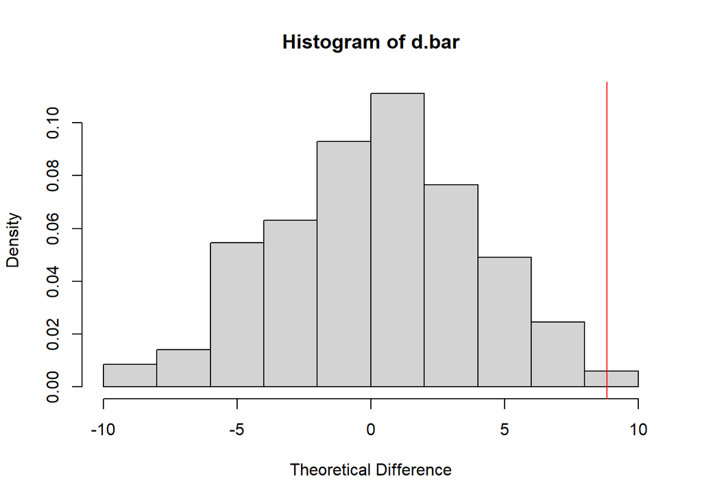

```
## [1] 0.012
```

Based on the above permutation test, we can see that the true mean of the difference is far from the mean of the theoretical distribution if there were no difference between samples. P-value = 0.012

```
##  2.5% 97.5%
##   4.5  13.0
```

From the bootstrap method, we get a 95% confidence interval of (4.5, 13.0) which represent the difference in means of hemoglobin increases for subjects with vs. without honey treatment.

# Question 4

Apply the permutation test with statistic $t = \bar{x} - \bar{y}$ to Example D, where x and y respectively refer to measurements for the oxygen gel and placebo gel groups. Construct boostrap confidence intervals for the difference of population means.

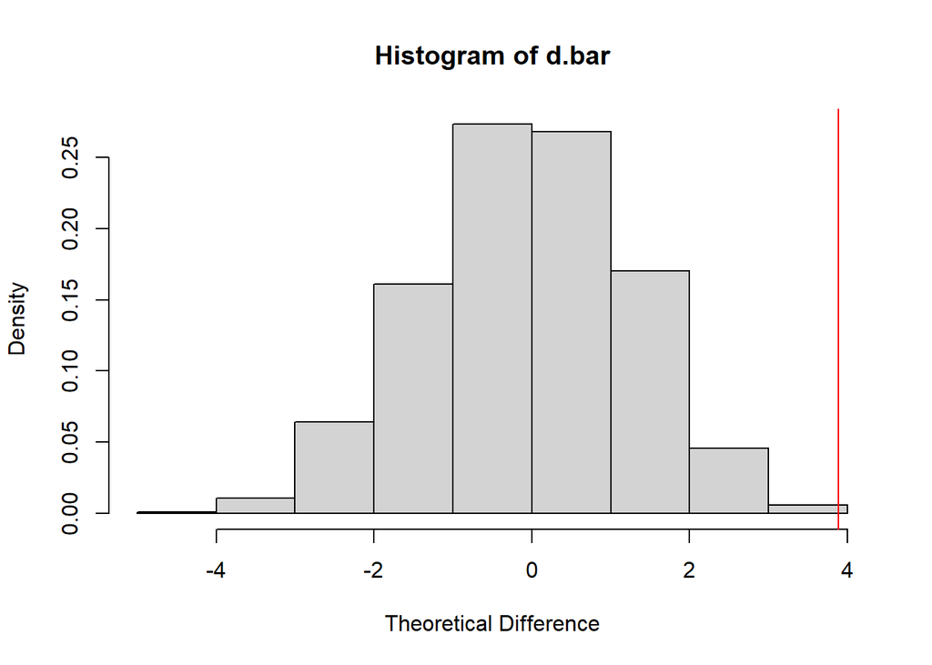

```
## [1] 0
```

```
##  2.5% 97.5%
##     2     7
```

From the bootstrap method, we get a 95% confidence interval of (2, 7) which represent the difference in means of oral hygeine index for subjects who took oxygen gels vs those who did not.

# Question 5

Discuss pros and cons between t and Wilcoxon tests. Conduct simulations to check your claims. Specifically, modify the simulation code i used in class to check the robustness of t test to departure from the normality assumption by generating sample from non-Gaussian distributions and compare powers of the t and Wilcoxon tests in these situations.

T-Test assumes interval data and a normal distribution and equal variances between groups. On the other hand, Wilcoxon tests use ranks instead of raw data and don’t require distribution assumptions. The Wilcoxon test is more flexibile, but less powerful when the assumptions of the T-Test are met.

```
##         [,1] [,2]  [,3]  [,4]  [,5]  [,6]  [,7]  [,8]  [,9] [,10] [,11] [,12]
## powert 1.000    1 0.995 0.968 0.897 0.753 0.549 0.334 0.175 0.065 0.064 0.132
## powerw 0.999    1 0.992 0.957 0.886 0.740 0.522 0.321 0.148 0.065 0.060 0.124
##        [,13] [,14] [,15] [,16] [,17] [,18] [,19] [,20]
## powert 0.318 0.594 0.750 0.910 0.970 0.992 1.000     1
## powerw 0.313 0.564 0.734 0.898 0.961 0.992 0.997     1
```

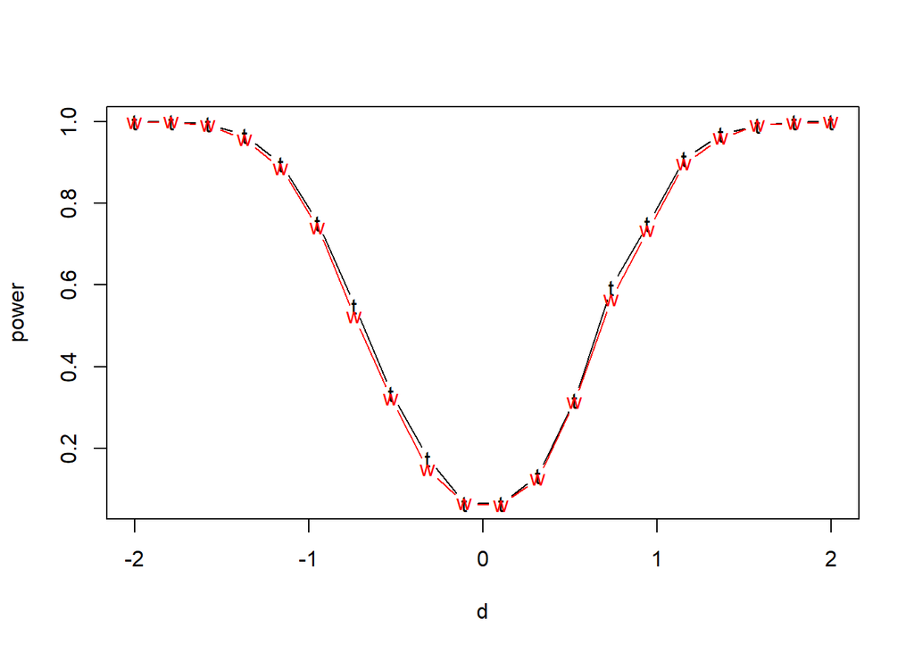

```
##        [,1]  [,2]  [,3]  [,4]  [,5] [,6]  [,7]  [,8]  [,9] [,10] [,11] [,12]
## powert   NA 0.061 0.241 0.444 0.605 0.72 0.801 0.891 0.926 0.954 0.962 0.973
## powerw   NA 1.000 1.000 1.000 1.000 1.00 1.000 1.000 1.000 1.000 1.000 1.000
##        [,13] [,14] [,15] [,16] [,17] [,18] [,19] [,20]
## powert 0.983 0.992 0.993 0.997 0.998 0.999     1     1
## powerw 1.000 1.000 1.000 1.000 1.000 1.000     1     1
```

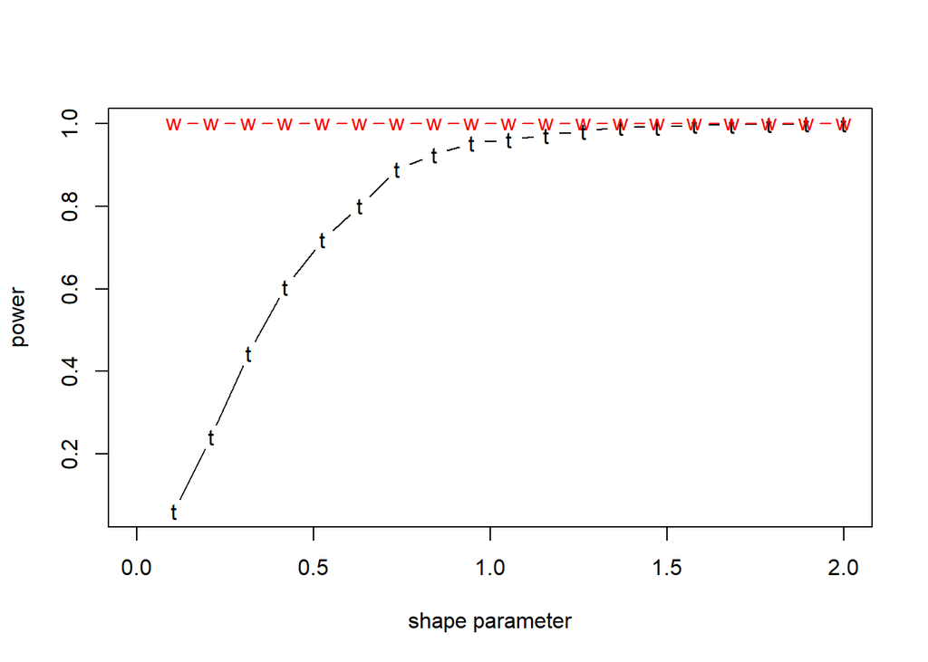

```
##         [,1]  [,2]  [,3]  [,4]  [,5]  [,6]  [,7]  [,8]  [,9] [,10] [,11] [,12]
## powert 0.874 0.867 0.886 0.887 0.868 0.877 0.877 0.856 0.872 0.872 0.883 0.875
## powerw 1.000 1.000 1.000 1.000 1.000 1.000 1.000 1.000 1.000 1.000 1.000 1.000
##        [,13] [,14] [,15] [,16] [,17] [,18] [,19] [,20]
## powert 0.869 0.861  0.88 0.876 0.878 0.875 0.871 0.881
## powerw 1.000 1.000  1.00 1.000 1.000 1.000 1.000 1.000
```

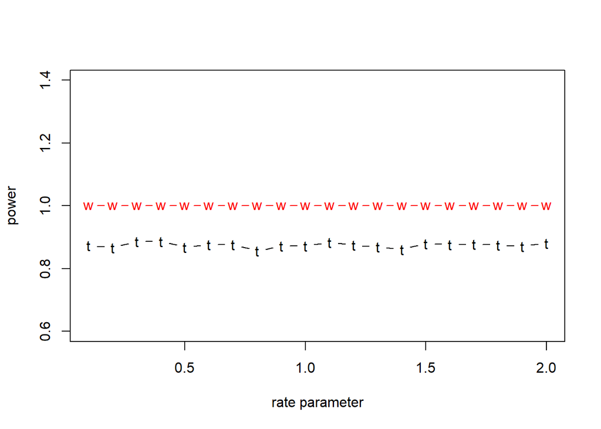

Above I conducted simulations of the performance of t-test and wilcoxon-tests for a normal distribution as well as gamma distributions (with varied shape paramters) and exponential distributions (with varied rate parameters).

For the Normal Distribution, we observe that for means close to zero, the t-test is slightly more powerful than the wilcoxon tests. As the |mean| increases, the two tests both approach a power of 1.

For the gamma distribution with a varied shape parameters, we observe that for shape parameters close to zero, the t-test performs quite poorly while the wilcoxon test performs very well. As the shape parameter increases, the distribution appears more normal, and the power of the t-test approaches 1 as well.

For the exponential distribution with varied rate parameter, the t-test performs fairly well with power ~ .9, but the wilcoxon test performs better with a power of ~1.

THese observations support the discussion in the beggining of this question, as the t-test performed better when it’s assumptions were met, but the wilcoxon test was much more flexible.

# Question 6

Write a R function for Z-test that compares the proportions from two independent groups. Include an option so that the user can specify one-sided or two-sided alternative hypothesis. Also include an option so that the user can specify the confidence level for confidence intervals. Output Zstatistic, p-value, estimates of proportion for each group, estimate of the difference and confidence intervals. Apply this function to Florida death penalty data.

Applying our Z-test to the Florida death-penalty data, we cannot reject the null that there is no correlation between race and death penalty. (Z-Stat = 0.471, P-Value = .639, CI = (-1.489, 2.430))

# Question 7

Write a R function for goodness-of-fit tests when category probabilities are completely specified. Applies your function to the linkage study of the tomato and the hour of birth examples.

Test on Tomato Data:

```
## [1] 1.4687220 3.0000000 0.6895079
```

From the goodness-of-fit test we get a p-val = .689 and cannot reject the null that the tomatoes are inconsistent with Mendel’s laws.

Test on hour-of-birth data:

```
## [1] 1.627757e+02 2.300000e+01 4.990700e-23
```

From the goodness-of-fit test we get a p-val << .05 and can reject the null that all birth-hours have equal probability.

# Question 8

Each individual in a random sample of high school and college students was cross-classified with respect to both political views and marijuana usage. Does the data support the hypothesis that political views and marijuana usage level are independent within the population?

Two categorical variables, will use chi-squared to check for correlation.

```
##
##  Pearson's Chi-squared test
##
## data:  pot_and_politics
## X-squared = 64.654, df = 4, p-value = 3.043e-13
```

From the Chi-Squared test, we see that there is a strong correlation between political identity and marijuana use. (P-Value << .05)

# Question 9

A certain type of flashlight is sold with the four batteries included. A random sample of 150 flashlights is obtained and the number of defective batteries in each is determined. Let X be the number of defective batteries in a randomly selected flashlight. Test the hypothesis that the distribution of X is Binomial.

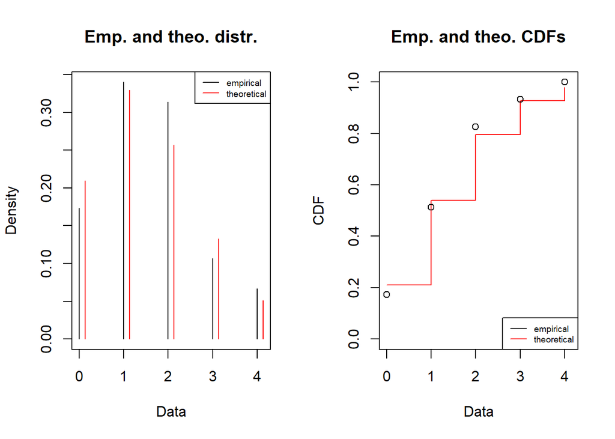

```
## [1] 4.3520236 4.0000000 0.6395441
```

# Question 10

Each of 325 individuals participating in a certain drug program was categorized both with respect to the presence or absence of hypoglycemia and with respect to mean daily dosage of insulin. Does the data support the claim that the presence/absence of hypoglycemia is independent of insulin dosage?

```
##
##  Pearson's Chi-squared test
##
## data:  m_absent
## X-squared = 1.5058, df = 4, p-value = 0.8256
```

We can test if hypoglycemia is independent of insulin dosage my projected theoretical hypoglycemia counts based on the total proportion of individuals of hypoglycemia to those without, and multiplying this proportion by the total counts of each insulin dose level. We can then compare these theoretical hypoglycemia counts with our observed counts via a chi-squared test. We get a p-value of .8256 and cannot reject the null that hypoglycemia is independant of insulin dosage.